# Enunciados junto con las soluciones

Jesús Manuel Falcón García, Marco Galliani, Ferran Garcia López, Soledad Gallego Benot

## Tablas de decisión:

### TABLA (A): Soledad Gallego Benot

|  | e1 | e2 | e3 |
| --- | --- | --- | --- |
| d1 | 88 | 160 | 130 |
| d2 | 125 | 200 | 233 |
| d3 | 136 | 230 | 98 |
| d4 | 95 | 190 | 106 |

*Solución Tabla (a)*:

#### Solución en caso favorable:

```
## $criterio
## [1] "Wald"
##
## $metodo
## [1] "favorable"
##
## $tablaX
##     e1  e2  e3
## d1  88 160 130
## d2 125 200 233
## d3 136 230  98
## d4  95 190 106
##
## $ValorAlternativas
##  d1  d2  d3  d4
##  88 125  98  95
##
## $ValorOptimo
## [1] 125
##
## $AlternativaOptima
## d2
##  2
```

```
## $criterio
## [1] "Optimista"
##
## $metodo
## [1] "favorable"
##
## $tablaX
##     e1  e2  e3
## d1  88 160 130
## d2 125 200 233
## d3 136 230  98
## d4  95 190 106
##
## $ValorAlternativas
##  d1  d2  d3  d4
## 160 233 230 190
##
## $ValorOptimo
## [1] 233
##
## $AlternativaOptima
## d2
##  2
```

```
## $criterio
## [1] "Hurwicz"
##
## $alfa
## [1] TRUE
##
## $metodo
## [1] "favorable"
##
## $tablaX
##     e1  e2  e3
## d1  88 160 130
## d2 125 200 233
## d3 136 230  98
## d4  95 190 106
##
## $ValorAlternativas
##  d1  d2  d3  d4
## 160 233 230 190
##
## $ValorOptimo
## [1] 233
##
## $AlternativaOptima
## d2
##  2
```

```
## $criterio
## [1] "Hurwicz"
##
## $alfa
## [1] 0.8
##
## $metodo
## [1] "favorable"
##
## $tablaX
##     e1  e2  e3
## d1  88 160 130
## d2 125 200 233
## d3 136 230  98
## d4  95 190 106
##
## $ValorAlternativas
##    d1    d2    d3    d4
## 145.6 211.4 203.6 171.0
##
## $ValorOptimo
## [1] 211.4
##
## $AlternativaOptima
## d2
##  2
```

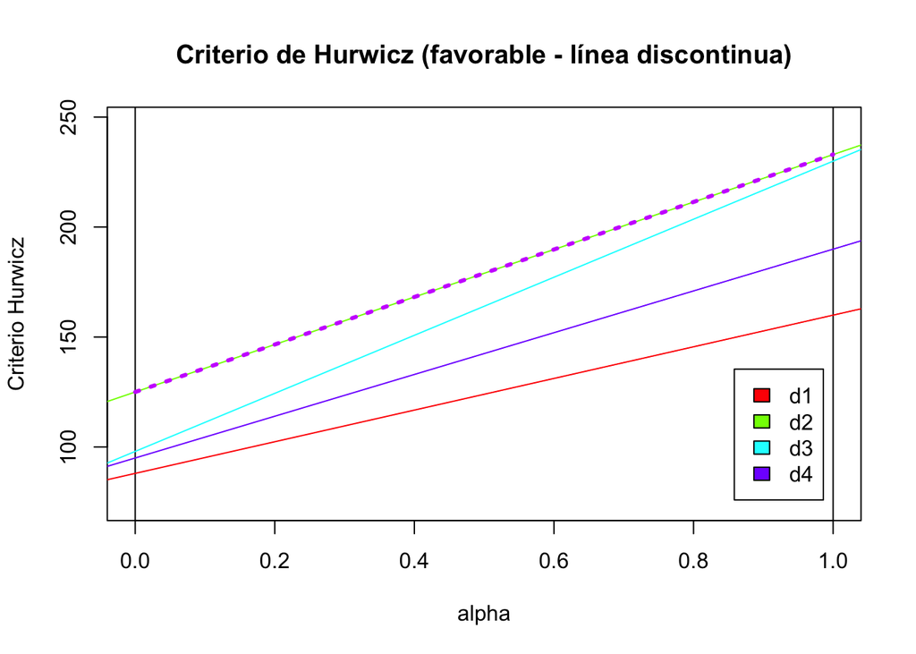

```
## $criterio
## [1] "Savage"
##
## $metodo
## [1] "favorable"
##
## $tablaX
##     e1  e2  e3
## d1  88 160 130
## d2 125 200 233
## d3 136 230  98
## d4  95 190 106
##
## $Mejores
##  e1  e2  e3
## 136 230 233
##
## $Pesos
##    e1 e2  e3
## d1 48 70 103
## d2 11 30   0
## d3  0  0 135
## d4 41 40 127
##
## $ValorAlternativas
##  d1  d2  d3  d4
## 103  30 135 127
##
## $ValorOptimo
## [1] 30
##
## $AlternativaOptima
## d2
##  2
```

```
## $criterio
## [1] "Laplace"
##
## $metodo
## [1] "favorable"
##
## $tablaX
##     e1  e2  e3
## d1  88 160 130
## d2 125 200 233
## d3 136 230  98
## d4  95 190 106
##
## $ValorAlternativas
##       d1       d2       d3       d4
## 126.0000 186.0000 154.6667 130.3333
##
## $ValorOptimo
## [1] 186
##
## $AlternativaOptima
## d2
##  2
```

```
## $criterio
## [1] "Punto Ideal"
##
## $metodo
## [1] "favorable"
##
## $tablaX
##     e1  e2  e3
## d1  88 160 130
## d2 125 200 233
## d3 136 230  98
## d4  95 190 106
##
## $Mejores
##  e1  e2  e3
## 136 230 233
##
## $ValorAlternativas
##        d1        d2        d3        d4
## 133.46535  31.95309 135.00000 139.31978
##
## $ValorOptimo
## [1] 31.95309
##
## $AlternativaOptima
## d2
##  2
```

**CONCLUSIÓN**: Podemos concluir, por lo tanto, que en situación favorable, es decir, tratándose de ganancias o beneficios, todos los criterios coinciden en que la mejor opción dada la anterior matriz de decisión es la d2

#### Solución en caso desfavorable:

```
## $criterio
## [1] "Wald"
##
## $metodo
## [1] "desfavorable"
##
## $tablaX
##     e1  e2  e3
## d1  88 160 130
## d2 125 200 233
## d3 136 230  98
## d4  95 190 106
##
## $ValorAlternativas
##  d1  d2  d3  d4
## 160 233 230 190
##
## $ValorOptimo
## [1] 160
##
## $AlternativaOptima
## d1
##  1
```

```
## $criterio
## [1] "Optimista"
##
## $metodo
## [1] "desfavorable"
##
## $tablaX
##     e1  e2  e3
## d1  88 160 130
## d2 125 200 233
## d3 136 230  98
## d4  95 190 106
##
## $ValorAlternativas
##  d1  d2  d3  d4
##  88 125  98  95
##
## $ValorOptimo
## [1] 88
##
## $AlternativaOptima
## d1
##  1
```

```
## $criterio
## [1] "Hurwicz"
##
## $alfa
## [1] 0.3
##
## $metodo
## [1] "desfavorable"
##
## $tablaX
##     e1  e2  e3
## d1  88 160 130
## d2 125 200 233
## d3 136 230  98
## d4  95 190 106
##
## $ValorAlternativas
##    d1    d2    d3    d4
## 138.4 200.6 190.4 161.5
##
## $ValorOptimo
## [1] 138.4
##
## $AlternativaOptima
## d1
##  1
```

```
## $criterio
## [1] "Hurwicz"
##
## $alfa
## [1] 0.8
##
## $metodo
## [1] "desfavorable"
##
## $tablaX
##     e1  e2  e3
## d1  88 160 130
## d2 125 200 233
## d3 136 230  98
## d4  95 190 106
##
## $ValorAlternativas
##    d1    d2    d3    d4
## 102.4 146.6 124.4 114.0
##
## $ValorOptimo
## [1] 102.4
##
## $AlternativaOptima
## d1
##  1
```

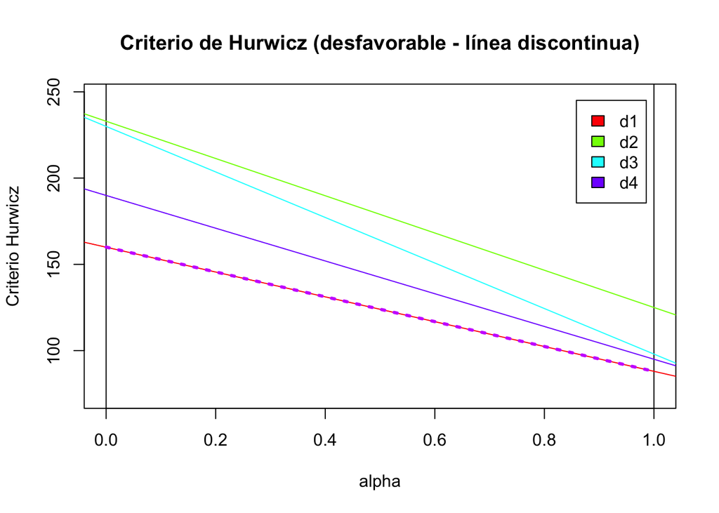

```
## d1 d4
## 32 30
```

```
## $criterio
## [1] "Laplace"
##
## $metodo
## [1] "desfavorable"
##
## $tablaX
##     e1  e2  e3
## d1  88 160 130
## d2 125 200 233
## d3 136 230  98
## d4  95 190 106
##
## $ValorAlternativas
##       d1       d2       d3       d4
## 126.0000 186.0000 154.6667 130.3333
##
## $ValorOptimo
## [1] 126
##
## $AlternativaOptima
## d1
##  1
```

```
## $criterio
## [1] "Punto Ideal"
##
## $metodo
## [1] "desfavorable"
##
## $tablaX
##     e1  e2  e3
## d1  88 160 130
## d2 125 200 233
## d3 136 230  98
## d4  95 190 106
##
## $Mejores
##  e1  e2  e3
##  88 160  98
##
## $ValorAlternativas
##        d1        d2        d3        d4
##  32.00000 145.58159  84.87638  31.82766
##
## $ValorOptimo
## [1] 31.82766
##
## $AlternativaOptima
## d4
##  4
```

**Conclusión**: Dado que la mayoría de los criterios consideran d1 como la opción más apropiada y que los que no lo hacen la consideran como segunda mejor alternativa y con muy poca diferencia con respecto a la que sería su alternativa óptima (d4), la opción óptima final sería d1.

### TABLA (B): Ferran Garcia López

|  | e1 | e2 | e3 | e4 | e5 | e6 | e7 | e8 | e9 | e10 |
| --- | --- | --- | --- | --- | --- | --- | --- | --- | --- | --- |
| d1 | 25 | 29 | 22 | 17 | 23 | 16 | 19 | 22 | 18 | 17 |
| d2 | 17 | 18 | 16 | 23 | 19 | 14 | 24 | 19 | 22 | 19 |
| d3 | 21 | 9 | 22 | 23 | 29 | 18 | 30 | 23 | 23 | 18 |
| d4 | 20 | 15 | 25 | 30 | 15 | 30 | 15 | 21 | 24 | 19 |
| d5 | 12 | 16 | 20 | 17 | 23 | 19 | 18 | 22 | 20 | 22 |
| d6 | 28 | 26 | 23 | 20 | 23 | 18 | 22 | 30 | 19 | 25 |
| d7 | 18 | 19 | 24 | 25 | 19 | 26 | 19 | 27 | 27 | 12 |
| d8 | 23 | 26 | 26 | 24 | 17 | 27 | 18 | 28 | 14 | 28 |
| d9 | 18 | 12 | 17 | 18 | 20 | 38 | 24 | 22 | 25 | 20 |
| d10 | 17 | 27 | 21 | 23 | 19 | 18 | 29 | 17 | 32 | 25 |
| d11 | 18 | 33 | 19 | 18 | 16 | 23 | 19 | 22 | 19 | 23 |
| d12 | 20 | 18 | 26 | 24 | 21 | 20 | 23 | 21 | 12 | 20 |
| d13 | 15 | 14 | 15 | 21 | 21 | 13 | 27 | 25 | 25 | 25 |
| d14 | 27 | 14 | 23 | 20 | 17 | 26 | 21 | 16 | 19 | 22 |
| d15 | 23 | 14 | 22 | 19 | 17 | 24 | 23 | 24 | 18 | 13 |

*Solución Tabla (b)*: #### Solución en caso favorable:

```
## Usando el criterio Optimista la alternativa óptima es d9 con un valor de 38
```

```
## Usando el criterio Wald la alternativa óptima es d6 con un valor de 18
```

```
## Usando el criterio Hurwicz con un alpha de 0.3 la alternativa óptima es d6 con un valor de 21.6
```

```
## Usando el criterio Laplace la alternativa óptima es d6 con un valor de 23.4
```

```
## Usando el criterio Savage la alternativa óptima es d11 con un valor de 15
```

```
## Usando el criterio Punto Ideal la alternativa óptima es d6 con un valor de 28.91366
```

Recogiendo las decisiones de todos los criterios:

| criterio | decision | valor |
| --- | --- | --- |
| Optimista | d9 | 38 |
| Wald | d6 | 18 |
| Hurwicz con alpha de 0.3 | d6 | 21.6 |
| Laplace | d6 | 23.4 |
| Savage | d11 | 15 |
| Punto Ideal | d6 | 28.91 |

#### Solución en caso desfavorable:

```
## Usando el criterio Optimista la alternativa óptima es d3 con un valor de 9
```

```
## Usando el criterio Wald la alternativa óptima es d5 con un valor de 23
```

```
## Usando el criterio Hurwicz con un alpha de 0.3 la alternativa óptima es d5 con un valor de 19.7
```

```
## Usando el criterio Laplace la alternativa óptima es d5 con un valor de 18.9
```

```
## Usando el criterio Savage la alternativa óptima es d2 d5 con un valor de 10
```

```
## Usando el criterio Punto Ideal la alternativa óptima es d5 con un valor de 19.57039
```

Recogiendo las decisiones de todos los criterios:

| criterio | decision | valor |
| --- | --- | --- |
| Optimista | d3 | 9 |
| Wald | d5 | 23 |
| Hurwicz con alpha de 0.3 | d5 | 19.7 |
| Laplace | d5 | 18.9 |
| Savage | d2, d5 | 10 |
| Punto Ideal | d5 | 19.57 |

### TABLA (C): Marco Galliani

|  | e1 | e2 | e3 | e4 | e5 | e6 | e7 | e8 | e9 | e10 | e11 |
| --- | --- | --- | --- | --- | --- | --- | --- | --- | --- | --- | --- |
| d1 | 1.9227956 | 1.0930421 | 0.5439560 | 0.3565044 | 1.8626272 | 0.8910948 | 0.0630385 | 0.9718176 | 1.4737807 | 0.7044855 | 3.1732797 |
| d2 | 1.5812022 | 5.7571905 | 0.0920660 | 0.3544414 | 1.8318082 | 0.1310732 | 0.7041387 | 0.4886055 | 0.6262955 | 3.0404385 | 1.4588033 |
| d3 | 0.3834669 | 0.3744587 | 0.0571306 | 0.6968438 | 0.6242158 | 1.3167732 | 0.6256910 | 1.1553158 | 0.6514291 | 1.4039621 | 1.1438264 |
| d4 | 0.5095021 | 2.2848813 | 0.1072336 | 0.9498671 | 1.6185042 | 4.6941616 | 0.6971087 | 0.0822742 | 0.1551562 | 1.8982052 | 0.3072510 |
| d5 | 0.4218837 | 0.6186527 | 0.7807989 | 0.2393121 | 0.0566404 | 1.9735234 | 3.8549705 | 1.6076501 | 0.2206629 | 0.0222299 | 0.0836233 |

*Solución Tabla (C)*:

#### Solución en caso favorable:

```r
ES_FAVORABLE <- TRUE
results <- computing_crit_results(tablaX = tabla1,
                                  favorable = ES_FAVORABLE,
                                  alfa = 0.5)
#results
table_sol <- list()
for(name in names(results)){
  table_sol[["Criterio"]] <- c(table_sol[["Criterio"]], results[[name]]$criterio)
  table_sol[["Alternativa Optima"]] <- c(table_sol[["Alternativa Optima"]], results[[name]]$AlternativaOptima)
}
names(table_sol) <- c("Criterio", "Alternativa Optima")
table_sol <- as.data.frame(table_sol)

knitr::kable(table_sol)
```

| Criterio | Alternativa.Optima |
| --- | --- |
| Wald | 2 |
| Optimista | 2 |
| Hurwicz | 2 |
| Laplace | 2 |
| Savage | 4 |
| Punto Ideal | 2 |

**CONCLUSIÓN**: La alternativa optima por todo los criterios es 2, excepto por el criterio de Savage que elige la alternativa 4. El criterio de Savage trata de minimizar el arrepentimiento. Si somos interesados a minimizar el arrepentimiento eligiremos la alternativa 4.